# PCAandFactorAnalysis

cvieira

August 4, 2020

### Learning Outcomes

By the end of this Activity, you will be able to:

- Invoke the kmeans algorithm to cluster individual students into groups
- Create different plots using the ggplot2 package to represent data from educational phenomena

Part of this tutorial was adapted from:

- http://r-statistics.co/Complete-Ggplot2-Tutorial-Part1-With-R-Code.html
- Our own work on visualizations
- Vieira, C., Parsons, P., & Byrd, V. (2018). Visual learning analytics of educational data: A systematic literature review and research agenda. Computers & Education, 122, 119-135.
- Vieira, C., Magana, A. J., Roy, A., & Falk, M. L. (2019). Student explanations in the context of computational science and engineering education. Cognition and Instruction, 37(2), 201-231.
- Magana, A. J., Fennell, H. W., Vieira, C., & Falk, M. L. (2019). Characterizing the interplay of cognitive and metacognitive knowledge in computational modeling and simulation practices. Journal of Engineering Education, 108(2), 276-303. ***

Since we want to use the plots from the library ggplot2, the first thing we need to do is to import this library.

```r
#install.packages('ggplot2')   # install it first if it is not installed yet
library(ggplot2)
library(tibble)
```

We also import the package tibble, which helps us with the kmeans clustering method.

#### Loading the Data

We first want to load some data, so we need to tell the computer where to get it from

Set the working directory to the folder where you have your files and read the file into a data frame

```r
#setwd('C:/Users/cvieira/Dropbox/Phd/Administrative/Mimi/FIE/2019/ScriptsAndData/data/')
setwd('C:/Users/cviei/Dropbox/Phd/Administrative/Mimi/FIE/2019/ScriptsAndData/data/')

typesOfKnowledge <- read.csv2("typesOfKnowledge.csv",header=TRUE,sep=",", row.names = 1)
meltedToK <- read.csv("meltedData.csv",header=TRUE,sep=",", row.names = 1)
```

### Activity

How are these two data frames different? Check them out

```r
head(typesOfKnowledge)
```

```
##             AnalyzeDeclarative SolveDeclarative Verify.InterpretDeclarative
## Alexis_(L)                2.75 2.33333333333333            2.33333333333333
## Armani_(H)                 2.5                3                           3
## Ash_(M)                      0                0                           0
## Charlie_(H)                2.5                2                           0
## Dakota_(H)                   0                0                           0
## Elliot_(L)    2.33333333333333 2.66666666666667                           0
##             MaintainDeclarative AnalyzeProcedural  SolveProcedural
## Alexis_(L)                    0                 0                3
## Armani_(H)                    0               2.5              3.5
## Ash_(M)                       0                 0                0
## Charlie_(H)                   0               2.5 3.33333333333333
## Dakota_(H)                    0                 0                0
## Elliot_(L)                    0                 3 2.33333333333333
##             Verify.InterpretProcedural MaintainProcedural AnalyzeSchematic
## Alexis_(L)                           2                  0                3
## Armani_(H)                         2.5                2.5                3
## Ash_(M)                              0                  0                0
## Charlie_(H)           3.33333333333333                  0              3.5
## Dakota_(H)                           0                  0                0
## Elliot_(L)                           0                  0                3
##             SolveSchematic Verify.InterpretSchematic MaintainSchematic
## Alexis_(L)             2.5                         0                 3
## Armani_(H)               0                       2.5                 3
## Ash_(M)                  0                         0                 0
## Charlie_(H)              0                         0                 0
## Dakota_(H)               0                         0                 0
## Elliot_(L)               0                         0                 0
##             AnalyzeStrategic   SolveStrategic Verify.InterpretStrategic
## Alexis_(L)                 3 2.66666666666667                       2.5
## Armani_(H)               2.5                2                         3
## Ash_(M)                    0                0                         0
## Charlie_(H)                3              3.5                         3
## Dakota_(H)                 0                0                         0
## Elliot_(L)                 3                2                         0
##             MaintainStrategic
## Alexis_(L)                  0
## Armani_(H)                  3
## Ash_(M)                     0
## Charlie_(H)                 0
## Dakota_(H)                  0
## Elliot_(L)                  0
```

```r
head(meltedToK)
```

```
##      Student Year LevelOne LevelTwo         ToK         variable      sum
## 1 Alexis_(L) 2015        L        L Declarative          Analyze 2.750000
## 2 Alexis_(L) 2015        L        L Declarative         Maintain       NA
## 3 Alexis_(L) 2015        L        L Declarative            Solve 2.333333
## 4 Alexis_(L) 2015        L        L Declarative Verify.Interpret 2.333333
## 5 Alexis_(L) 2015        L        L  Procedural          Analyze       NA
## 6 Alexis_(L) 2015        L        L  Procedural         Maintain       NA
```

#### Let’s get to the clusters now…

We need to set a seed to always get the same set of clusters for the same data

And then we use kmeans function to identify four clusters in the data set.

```r
set.seed(1234)
stdClusters<- kmeans(typesOfKnowledge, 4)
stdClusters #Check out the cluster for each student
```

```
## K-means clustering with 4 clusters of sizes 4, 4, 3, 6
##
## Cluster means:
##   AnalyzeDeclarative SolveDeclarative Verify.InterpretDeclarative
## 1           2.375000         2.583333                   2.1250000
## 2           2.645833         1.833333                   2.3333333
## 3           2.611111         2.488889                   0.8333333
## 4           0.000000         0.000000                   0.0000000
##   MaintainDeclarative AnalyzeProcedural SolveProcedural
## 1                   0          1.750000        3.075000
## 2                   0          2.000000        3.291667
## 3                   0          2.833333        3.055556
## 4                   0          0.000000        0.000000
##   Verify.InterpretProcedural MaintainProcedural AnalyzeSchematic SolveSchematic
## 1                   1.125000              1.125            1.125          0.000
## 2                   2.416667              0.750            2.500          2.875
## 3                   1.944444              0.000            3.500          0.000
## 4                   0.000000              0.000            0.000          0.000
##   Verify.InterpretSchematic MaintainSchematic AnalyzeStrategic SolveStrategic
## 1                 1.7500000              1.75            2.500       2.625000
## 2                 1.6250000              2.25            2.375       2.500000
## 3                 0.8333333              0.00            2.000       2.833333
## 4                 0.0000000              0.00            0.000       0.000000
##   Verify.InterpretStrategic MaintainStrategic
## 1                     2.375              2.50
## 2                     2.000              0.75
## 3                     2.000              0.00
## 4                     0.000              0.00
##
## Clustering vector:
##  Alexis_(L)  Armani_(H)     Ash_(M) Charlie_(H)  Dakota_(H)  Elliot_(L)
##           2           1           4           3           4           3
## Emerson_(M)  Harper_(M)  Jessie_(H) Justice_(M)  Landry_(H)  Lennon_(M)
##           3           4           2           2           4           1
##   Logan_(L)   Milan_(L)  Oakley_(M) Phoenix_(M)    Remy_(H)
##           1           2           4           1           4
##
## Within cluster sum of squares by cluster:
## [1] 34.63556 45.39410 29.58963  0.00000
##  (between_SS / total_SS =  73.8 %)
##
## Available components:
##
## [1] "cluster"      "centers"      "totss"        "withinss"     "tot.withinss"
## [6] "betweenss"    "size"         "iter"         "ifault"
```

We need to transform the matrix into a data frame to map the clusters.

The as.factor function transforms a numerical variable into a categorical variable

```r
groups<- as.data.frame(typesOfKnowledge)

groups$stdClusters<- as.factor(stdClusters$cluster)
groups <- rownames_to_column(groups, "std") #The students are as row names and we need to have them as column to merge them later
```

Assign the clusters to each student in the melted format (which we will use to plot)

Make sure R recognizes the cluster as a categorical variable (it should not be a number!)

```r
meltedToK <- merge(meltedToK,groups[,c('std','stdClusters')], by.x = 'Student', by.y = 'std')
meltedToK$stdClusters <- factor(meltedToK$stdClusters, levels=c("1", "2","3","4"))
```

Now we can create the plot using ggplot.

Note that our X axis will have an interaction between the Types of Knowledge and the Steps of de modeling process (variable)

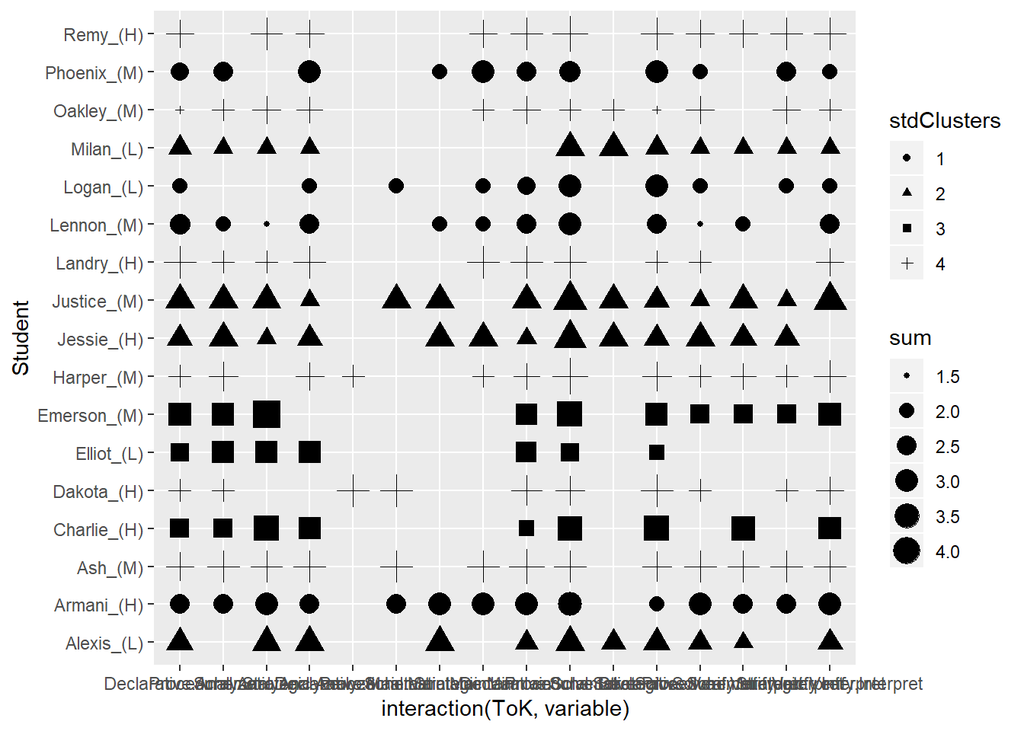

```r
ggplot(meltedToK, aes(x=interaction(ToK,variable),Student))+
  geom_point(aes(size=sum, shape=stdClusters))
```

The plot is ready, but it is better to see it organized, so we can do the following:

1. Get the list of students in order based on the clusters.
2. Use that to organize the students in the data frame

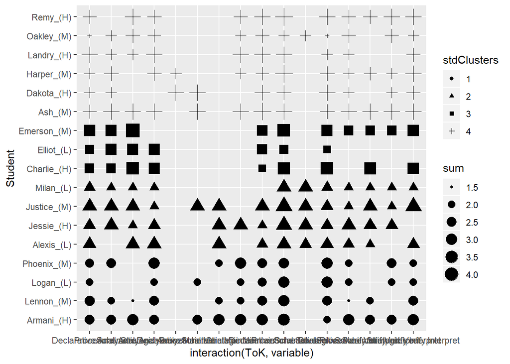

```r
students <- groups[order(groups$stdClusters),]$std

meltedToK$Student <- factor(meltedToK$Student, levels=students)

#Plot it again:
ggplot(meltedToK, aes(x=interaction(ToK,variable),Student))+
  geom_point(aes(size=sum, shape=stdClusters))
```

What else would you need to change?